# Modeling and prediction for movies

## Setup

### Load packages

```r
library(ggplot2)
library(dplyr)
library(statsr)
library(caret)
```

### Load data

Make sure your data and R Markdown files are in the same directory. When loaded your data file will be called `movies`. Delete this note when before you submit your work.

```r
load("movies.rdata")
movies_table <-dplyr::tbl_df(movies)
movies_table_model<-dplyr::select(movies_table, title,genre, runtime, mpaa_rating, imdb_rating, imdb_num_votes, critics_rating, critics_score, audience_rating, audience_score, top200_box)
movies_table_model
```

```
## # A tibble: 651 × 11
##                     title       genre runtime mpaa_rating imdb_rating
##                     <chr>      <fctr>   <dbl>      <fctr>       <dbl>
## 1             Filly Brown       Drama      80           R         5.5
## 2                The Dish       Drama     101       PG-13         7.3
## 3     Waiting for Guffman      Comedy      84           R         7.6
## 4    The Age of Innocence       Drama     139          PG         7.2
## 5             Malevolence      Horror      90           R         5.1
## 6             Old Partner Documentary      78     Unrated         7.8
## 7               Lady Jane       Drama     142       PG-13         7.2
## 8            Mad Dog Time       Drama      93           R         5.5
## 9  Beauty Is Embarrassing Documentary      88     Unrated         7.5
## 10   The Snowtown Murders       Drama     119     Unrated         6.6
## # ... with 641 more rows, and 6 more variables: imdb_num_votes <int>,
## #   critics_rating <fctr>, critics_score <dbl>, audience_rating <fctr>,
## #   audience_score <dbl>, top200_box <fctr>
```

## Part 1: Data

The data set is comprised of 651 randomly sampled movies produced and released in 2016 The fields of the data are as listed below:

1. `title`: Title of movie
2. `title_type`: Type of movie (Documentary, Feature Film, TV Movie)
3. `genre`: Genre of movie (Action & Adventure, Comedy, Documentary, Drama, Horror, Mystery & Suspense, Other)
4. `runtime`: Runtime of movie (in minutes)
5. `mpaa_rating`: MPAA rating of the movie (G, PG, PG-13, R, Unrated)
6. `studio`: Studio that produced the movie
7. `thtr_rel_year`: Year the movie is released in theaters
8. `thtr_rel_month`: Month the movie is released in theaters
9. `thtr_rel_day`: Day of the month the movie is released in theaters
10. `dvd_rel_year`: Year the movie is released on DVD
11. `dvd_rel_month`: Month the movie is released on DVD
12. `dvd_rel_day`: Day of the month the movie is released on DVD
13. `imdb_rating`: Rating on IMDB
14. `imdb_num_votes`: Number of votes on IMDB
15. `critics_rating`: Categorical variable for critics rating on Rotten Tomatoes (Certified Fresh, Fresh, Rotten)
16. `critics_score`: Critics score on Rotten Tomatoes
17. `audience_rating`: Categorical variable for audience rating on Rotten Tomatoes (Spilled, Upright)
18. `audience_score`: Audience score on Rotten Tomatoes
19. `best_pic_nom`: Whether or not the movie was nominated for a best picture Oscar (no, yes)
20. `best_pic_win`: Whether or not the movie won a best picture Oscar (no, yes)
21. `best_actor_win`: Whether or not one of the main actors in the movie ever won an Oscar (no, yes) – note that this is not necessarily whether the actor won an Oscar for their role in the given movie
22. `best_actress win`: Whether or not one of the main actresses in the movie ever won an Oscar (no, yes) – not that this is not necessarily whether the actresses won an Oscar for their role in the given movie
23. `best_dir_win`: Whether or not the director of the movie ever won an Oscar (no, yes) – not that this is not necessarily whether the director won an Oscar for the given movie
24. `top200_box`: Whether or not the movie is in the Top 200 Box Office list on BoxOfficeMojo (no, yes)
25. `director`: Director of the movie
26. `actor1`: First main actor/actress in the abridged cast of the movie
27. `actor2`: Second main actor/actress in the abridged cast of the movie
28. `actor3`: Third main actor/actress in the abridged cast of the movie
29. `actor4`: Fourth main actor/actress in the abridged cast of the movie
30. `actor5`: Fifth main actor/actress in the abridged cast of the movie
31. `imdb_url`: Link to IMDB page for the movie
32. `rt_url`: Link to Rotten Tomatoes page for the movie

## Part 2: Research question

Is there any association between how the critic’s score to the audience’s score ?  
Which among the following: critics score, imdb number of votes, imdb rating , critics rating is highly likely to influence the audience score ?

## Part 3: Exploratory data analysis

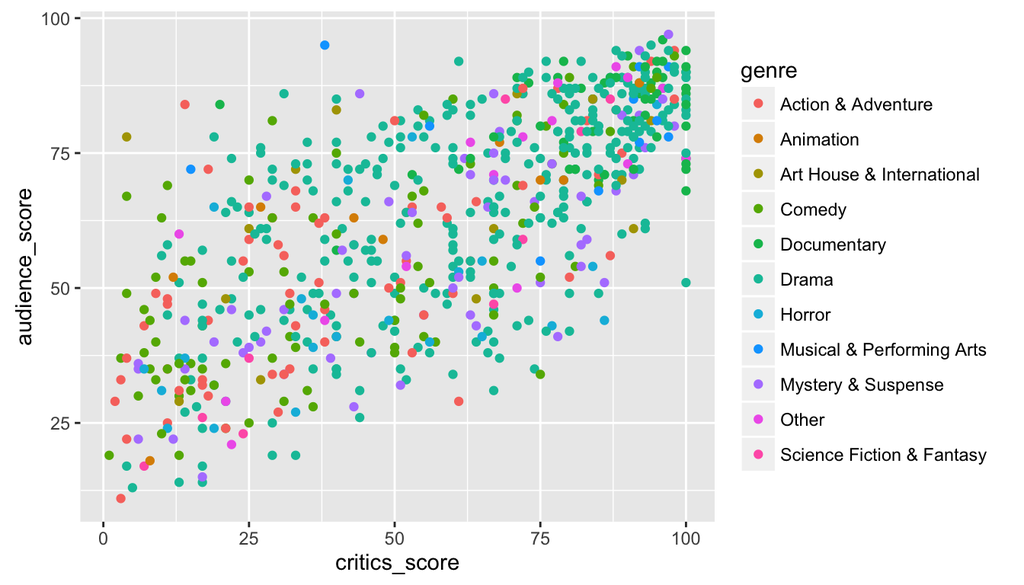

```r
qplot(critics_score,audience_score,colour=genre, data=movies_table_model)
```

Same Graph colored the Critics Rating - in this graph we can see that Certified Fresh and Fresh tend to get a higher audience score

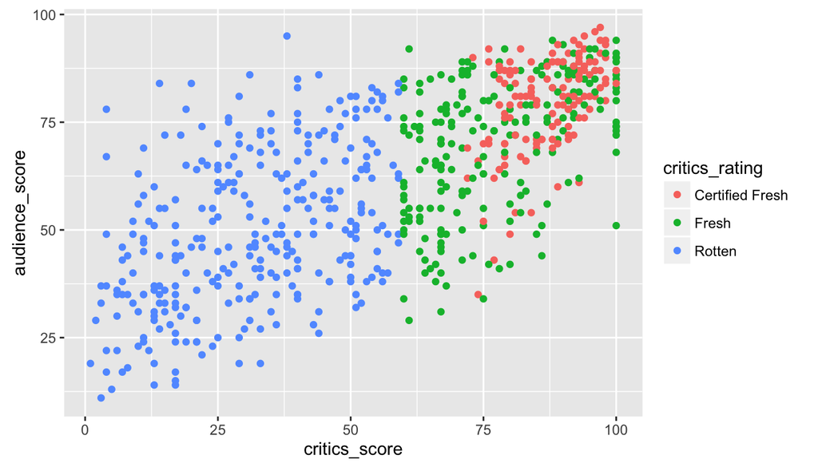

```r
qplot(critics_score,audience_score,colour=critics_rating, data=movies_table_model)
```

Same Graph colored the MPAA Rating for the movie

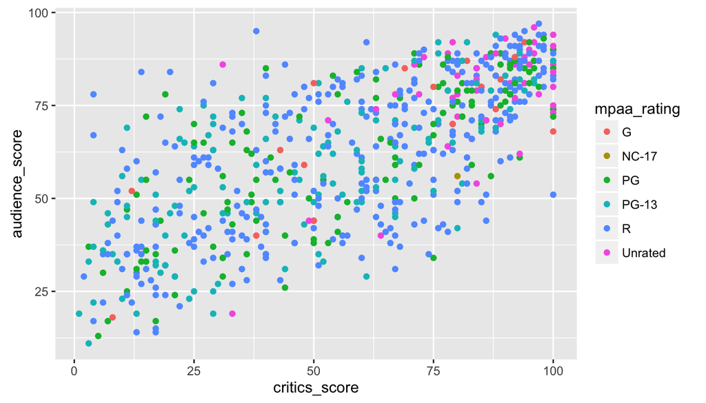

```r
qplot(critics_score,audience_score,colour=mpaa_rating, data=movies_table_model)
```

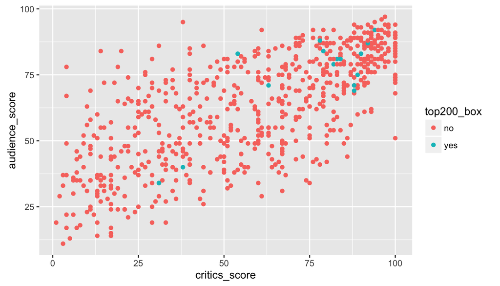

```r
qplot(critics_score,audience_score,colour=top200_box, data=movies_table_model)
```

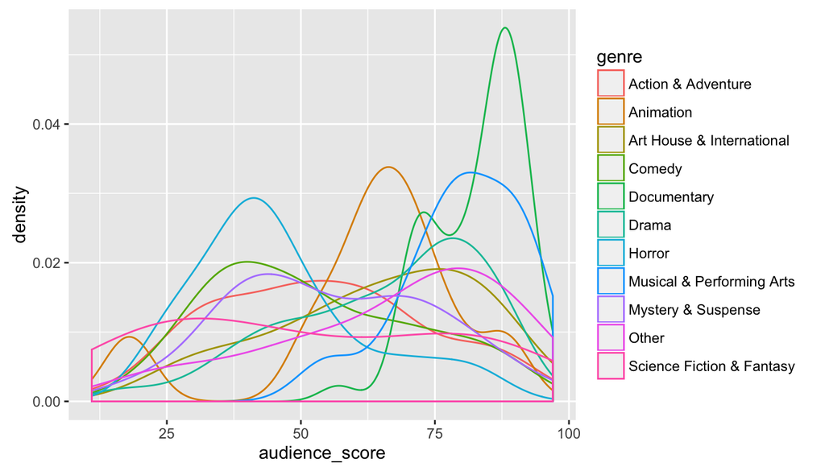

```r
qplot(audience_score,colour=genre, data=movies_table_model, geom="density")
```

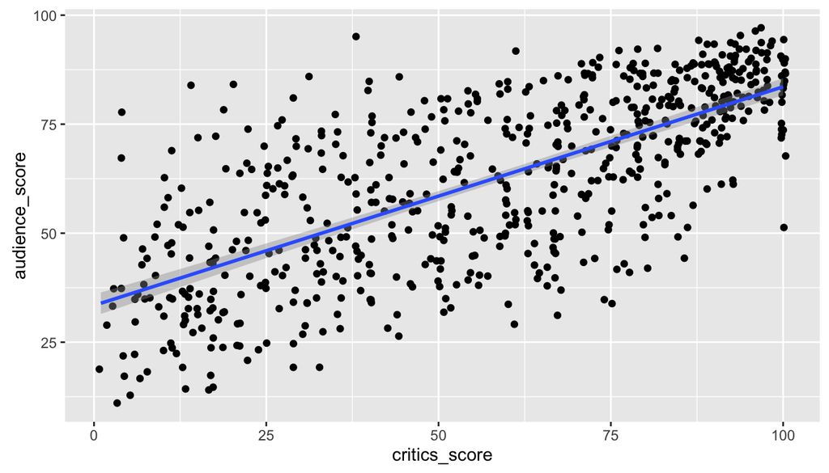

```r
ggplot(data = movies_table_model, aes(x = critics_score, y = audience_score)) +
    geom_jitter() +
  geom_smooth(method = "lm")
```

Looks like it might have a linear relationship.

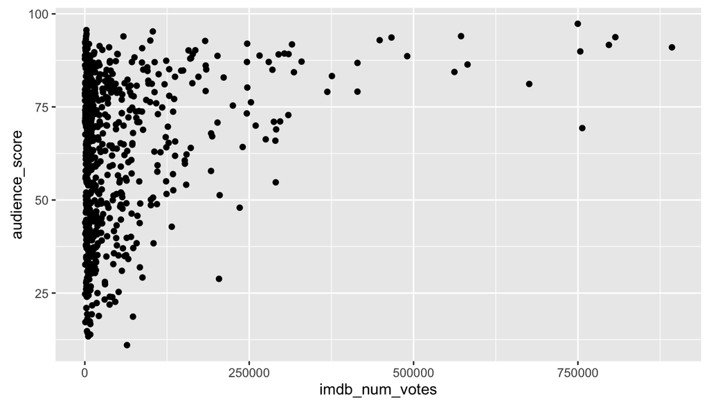

```r
ggplot(data = movies_table_model, aes(x = imdb_num_votes, y = audience_score)) +
    geom_jitter()
```

```r
movies_table_model %>% summarize(cor(audience_score, imdb_num_votes))
```

```
## # A tibble: 1 × 1
##   `cor(audience_score, imdb_num_votes)`
##                                   <dbl>
## 1                             0.2898128
```

## Part 4: Modeling

Let us model the relationship between the audience_score the following for the full model -> genre, runtime, mpaa_rating, imdb_rating, imdb_num_votes, critics_rating, critics_score Looks like mpaa rating is not a strong indicator

```r
m_critics1 <- lm(audience_score ~ genre + runtime + mpaa_rating + imdb_rating + imdb_num_votes + critics_rating + critics_score, data = movies_table_model)
summary(m_critics1)
```

```
##
## Call:
## lm(formula = audience_score ~ genre + runtime + mpaa_rating +
##     imdb_rating + imdb_num_votes + critics_rating + critics_score,
##     data = movies_table_model)
##
## Residuals:
##     Min      1Q  Median      3Q     Max
## -27.270  -6.304   0.468   5.667  49.182
##
## Coefficients:
##                                  Estimate Std. Error t value Pr(>|t|)
## (Intercept)                    -2.723e+01  4.900e+00  -5.556 4.07e-08 ***
## genreAnimation                  7.776e+00  3.827e+00   2.032   0.0426 *
## genreArt House & International -1.500e-01  2.990e+00  -0.050   0.9600
## genreComedy                     2.035e+00  1.631e+00   1.247   0.2127
## genreDocumentary                1.052e+00  2.292e+00   0.459   0.6464
## genreDrama                      4.848e-01  1.434e+00   0.338   0.7354
## genreHorror                    -5.073e+00  2.444e+00  -2.076   0.0383 *
## genreMusical & Performing Arts  5.198e+00  3.187e+00   1.631   0.1034
## genreMystery & Suspense        -5.506e+00  1.828e+00  -3.012   0.0027 **
## genreOther                      1.510e+00  2.770e+00   0.545   0.5859
## genreScience Fiction & Fantasy -9.231e-01  3.502e+00  -0.264   0.7922
## runtime                        -4.596e-02  2.296e-02  -2.002   0.0457 *
## mpaa_ratingNC-17               -4.448e+00  7.421e+00  -0.599   0.5491
## mpaa_ratingPG                   9.615e-01  2.702e+00   0.356   0.7220
## mpaa_ratingPG-13               -6.938e-01  2.789e+00  -0.249   0.8036
## mpaa_ratingR                   -3.703e-01  2.684e+00  -0.138   0.8903
## mpaa_ratingUnrated              9.499e-01  3.064e+00   0.310   0.7566
## imdb_rating                     1.494e+01  6.211e-01  24.055  < 2e-16 ***
## imdb_num_votes                  3.595e-06  4.364e-06   0.824   0.4103
## critics_ratingFresh            -2.052e+00  1.217e+00  -1.686   0.0923 .
## critics_ratingRotten           -4.762e+00  1.977e+00  -2.408   0.0163 *
## critics_score                   1.949e-03  3.574e-02   0.055   0.9565
## ---
## Signif. codes:  0 '***' 0.001 '**' 0.01 '*' 0.05 '.' 0.1 ' ' 1
##
## Residual standard error: 9.781 on 628 degrees of freedom
##   (1 observation deleted due to missingness)
## Multiple R-squared:  0.7739, Adjusted R-squared:  0.7664
## F-statistic: 102.4 on 21 and 628 DF,  p-value: < 2.2e-16
```

Let’s remove mpaa rating is not a strong indicator

```r
m_critics2 <- lm(audience_score ~ genre + runtime + imdb_rating + imdb_num_votes + critics_rating + critics_score, data = movies_table_model)
summary(m_critics2)
```

```
##
## Call:
## lm(formula = audience_score ~ genre + runtime + imdb_rating +
##     imdb_num_votes + critics_rating + critics_score, data = movies_table_model)
##
## Residuals:
##     Min      1Q  Median      3Q     Max
## -26.118  -5.979   0.452   5.650  49.099
##
## Coefficients:
##                                  Estimate Std. Error t value Pr(>|t|)
## (Intercept)                    -2.753e+01  4.207e+00  -6.543 1.25e-10 ***
## genreAnimation                  8.057e+00  3.501e+00   2.301   0.0217 *
## genreArt House & International -1.503e-01  2.925e+00  -0.051   0.9590
## genreComedy                     1.861e+00  1.611e+00   1.155   0.2484
## genreDocumentary                1.418e+00  2.062e+00   0.688   0.4919
## genreDrama                      1.756e-01  1.394e+00   0.126   0.8998
## genreHorror                    -5.274e+00  2.387e+00  -2.210   0.0275 *
## genreMusical & Performing Arts  5.187e+00  3.161e+00   1.641   0.1014
## genreMystery & Suspense        -5.884e+00  1.780e+00  -3.305   0.0010 **
## genreOther                      1.721e+00  2.753e+00   0.625   0.5320
## genreScience Fiction & Fantasy -8.504e-01  3.491e+00  -0.244   0.8076
## runtime                        -4.652e-02  2.256e-02  -2.062   0.0397 *
## imdb_rating                     1.494e+01  6.176e-01  24.194  < 2e-16 ***
## imdb_num_votes                  2.863e-06  4.308e-06   0.665   0.5065
## critics_ratingFresh            -1.957e+00  1.212e+00  -1.615   0.1067
## critics_ratingRotten           -4.546e+00  1.965e+00  -2.314   0.0210 *
## critics_score                   7.852e-03  3.532e-02   0.222   0.8241
## ---
## Signif. codes:  0 '***' 0.001 '**' 0.01 '*' 0.05 '.' 0.1 ' ' 1
##
## Residual standard error: 9.762 on 633 degrees of freedom
##   (1 observation deleted due to missingness)
## Multiple R-squared:  0.773,  Adjusted R-squared:  0.7672
## F-statistic: 134.7 on 16 and 633 DF,  p-value: < 2.2e-16
```

Let’s remove critics score is not really as strong indicator.

```r
m_critics3 <- lm(audience_score ~ genre + runtime + imdb_rating + imdb_num_votes + critics_rating, data = movies_table_model)
summary(m_critics3)
```

```
##
## Call:
## lm(formula = audience_score ~ genre + runtime + imdb_rating +
##     imdb_num_votes + critics_rating, data = movies_table_model)
##
## Residuals:
##     Min      1Q  Median      3Q     Max
## -26.035  -6.046   0.477   5.592  49.049
##
## Coefficients:
##                                  Estimate Std. Error t value Pr(>|t|)
## (Intercept)                    -2.740e+01  4.164e+00  -6.579  9.9e-11 ***
## genreAnimation                  8.070e+00  3.498e+00   2.307 0.021367 *
## genreArt House & International -1.964e-01  2.915e+00  -0.067 0.946312
## genreComedy                     1.867e+00  1.610e+00   1.160 0.246623
## genreDocumentary                1.445e+00  2.057e+00   0.702 0.482679
## genreDrama                      1.870e-01  1.392e+00   0.134 0.893147
## genreHorror                    -5.254e+00  2.383e+00  -2.204 0.027865 *
## genreMusical & Performing Arts  5.213e+00  3.157e+00   1.651 0.099185 .
## genreMystery & Suspense        -5.882e+00  1.779e+00  -3.307 0.000998 ***
## genreOther                      1.739e+00  2.750e+00   0.633 0.527224
## genreScience Fiction & Fantasy -8.510e-01  3.489e+00  -0.244 0.807354
## runtime                        -4.629e-02  2.252e-02  -2.055 0.040268 *
## imdb_rating                     1.501e+01  5.232e-01  28.700  < 2e-16 ***
## imdb_num_votes                  2.721e-06  4.257e-06   0.639 0.522986
## critics_ratingFresh            -2.015e+00  1.183e+00  -1.704 0.088830 .
## critics_ratingRotten           -4.873e+00  1.298e+00  -3.756 0.000189 ***
## ---
## Signif. codes:  0 '***' 0.001 '**' 0.01 '*' 0.05 '.' 0.1 ' ' 1
##
## Residual standard error: 9.755 on 634 degrees of freedom
##   (1 observation deleted due to missingness)
## Multiple R-squared:  0.773,  Adjusted R-squared:  0.7676
## F-statistic: 143.9 on 15 and 634 DF,  p-value: < 2.2e-16
```

Let’s remove imdb votes

```r
m_critics3 <- lm(audience_score ~ genre + runtime + imdb_rating + critics_rating, data = movies_table_model)
summary(m_critics3)
```

```
##
## Call:
## lm(formula = audience_score ~ genre + runtime + imdb_rating +
##     critics_rating, data = movies_table_model)
##
## Residuals:
##     Min      1Q  Median      3Q     Max
## -26.036  -6.019   0.599   5.575  49.175
##
## Coefficients:
##                                 Estimate Std. Error t value Pr(>|t|)
## (Intercept)                    -27.90462    4.08624  -6.829 2.00e-11 ***
## genreAnimation                   8.03284    3.49580   2.298 0.021894 *
## genreArt House & International  -0.44754    2.88716  -0.155 0.876862
## genreComedy                      1.81976    1.60740   1.132 0.258014
## genreDocumentary                 1.11257    1.98951   0.559 0.576212
## genreDrama                       0.04222    1.37264   0.031 0.975471
## genreHorror                     -5.32295    2.37988  -2.237 0.025656 *
## genreMusical & Performing Arts   4.88807    3.11428   1.570 0.117014
## genreMystery & Suspense         -5.92951    1.77663  -3.337 0.000895 ***
## genreOther                       1.76351    2.74809   0.642 0.521285
## genreScience Fiction & Fantasy  -0.81231    3.48644  -0.233 0.815843
## runtime                         -0.04258    0.02175  -1.957 0.050730 .
## imdb_rating                     15.10176    0.50487  29.912  < 2e-16 ***
## critics_ratingFresh             -2.27666    1.10903  -2.053 0.040498 *
## critics_ratingRotten            -5.07158    1.25938  -4.027 6.33e-05 ***
## ---
## Signif. codes:  0 '***' 0.001 '**' 0.01 '*' 0.05 '.' 0.1 ' ' 1
##
## Residual standard error: 9.75 on 635 degrees of freedom
##   (1 observation deleted due to missingness)
## Multiple R-squared:  0.7728, Adjusted R-squared:  0.7678
## F-statistic: 154.3 on 14 and 635 DF,  p-value: < 2.2e-16
```

```r
m_critics4 <- lm(audience_score ~  genre + imdb_rating + critics_rating, data = movies_table_model)
summary(m_critics4)
```

```
##
## Call:
## lm(formula = audience_score ~ genre + imdb_rating + critics_rating,
##     data = movies_table_model)
##
## Residuals:
##     Min      1Q  Median      3Q     Max
## -25.562  -6.045   0.419   5.672  48.943
##
## Coefficients:
##                                Estimate Std. Error t value Pr(>|t|)
## (Intercept)                    -30.9149     3.7910  -8.155 1.86e-15 ***
## genreAnimation                   8.7118     3.4852   2.500 0.012682 *
## genreArt House & International  -0.2559     2.8912  -0.089 0.929500
## genreComedy                      2.0575     1.6060   1.281 0.200624
## genreDocumentary                 1.5735     1.9598   0.803 0.422327
## genreDrama                      -0.1319     1.3724  -0.096 0.923449
## genreHorror                     -4.8825     2.3740  -2.057 0.040127 *
## genreMusical & Performing Arts   4.7166     3.1192   1.512 0.130999
## genreMystery & Suspense         -6.1181     1.7774  -3.442 0.000615 ***
## genreOther                       1.5508     2.7513   0.564 0.573192
## genreScience Fiction & Fantasy  -0.7758     3.4933  -0.222 0.824317
## imdb_rating                     14.8726     0.4920  30.231  < 2e-16 ***
## critics_ratingFresh             -2.2086     1.1092  -1.991 0.046888 *
## critics_ratingRotten            -5.1401     1.2614  -4.075 5.19e-05 ***
## ---
## Signif. codes:  0 '***' 0.001 '**' 0.01 '*' 0.05 '.' 0.1 ' ' 1
##
## Residual standard error: 9.77 on 637 degrees of freedom
## Multiple R-squared:  0.7713, Adjusted R-squared:  0.7666
## F-statistic: 165.2 on 13 and 637 DF,  p-value: < 2.2e-16
```

Let’s look at some diagnostics for the linear model

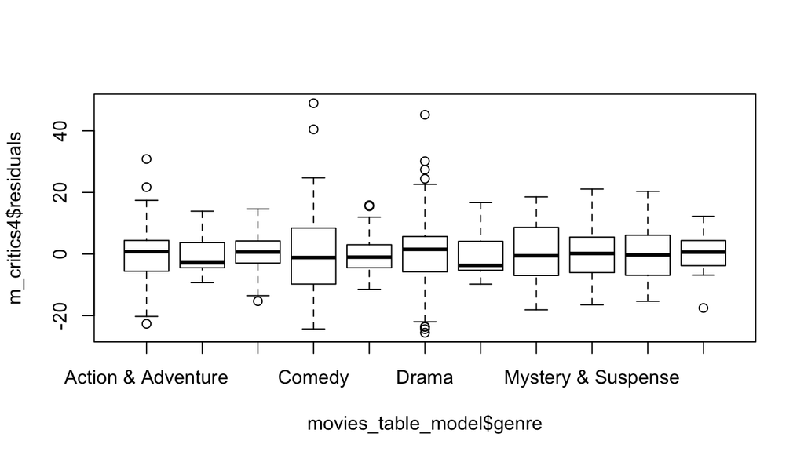

```r
plot(m_critics4$residuals ~ movies_table_model$genre)
```

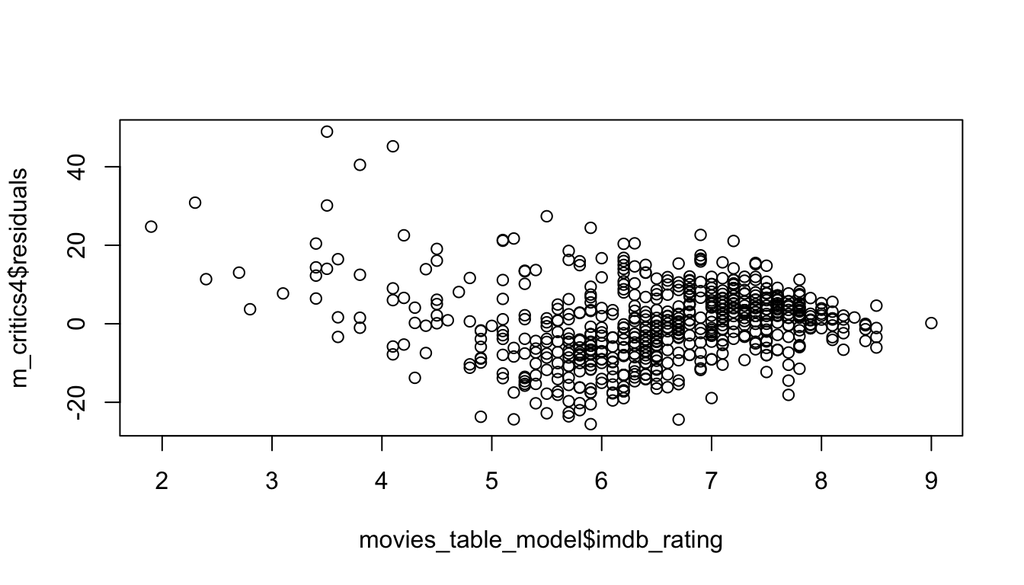

```r
plot(m_critics4$residuals ~ movies_table_model$imdb_rating)
```

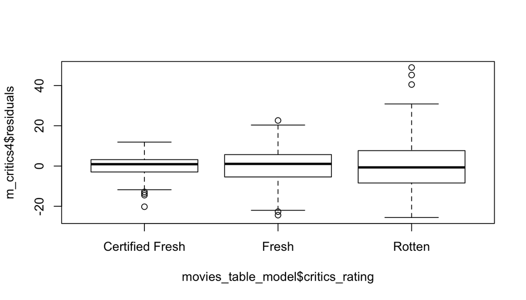

```r
plot(m_critics4$residuals ~ movies_table_model$critics_rating)
```

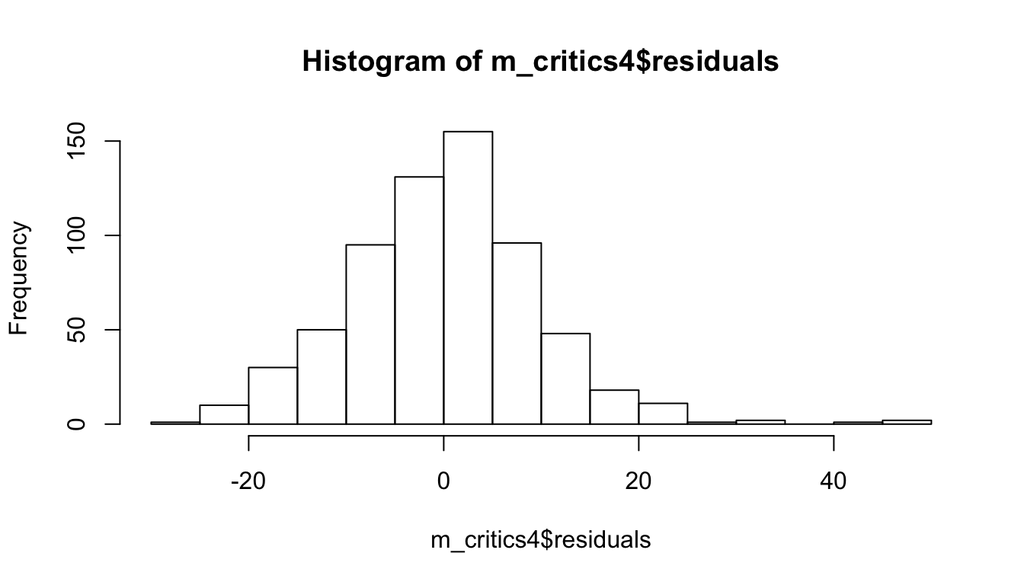

```r
hist(m_critics4$residuals)
```

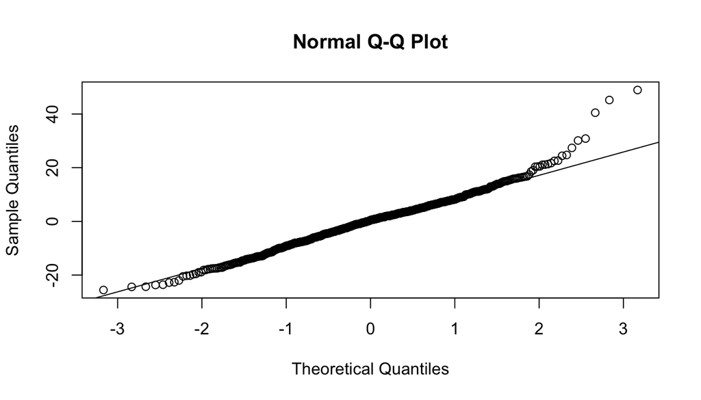

```r
qqnorm(m_critics4$residuals)
qqline(m_critics4$residuals)
```

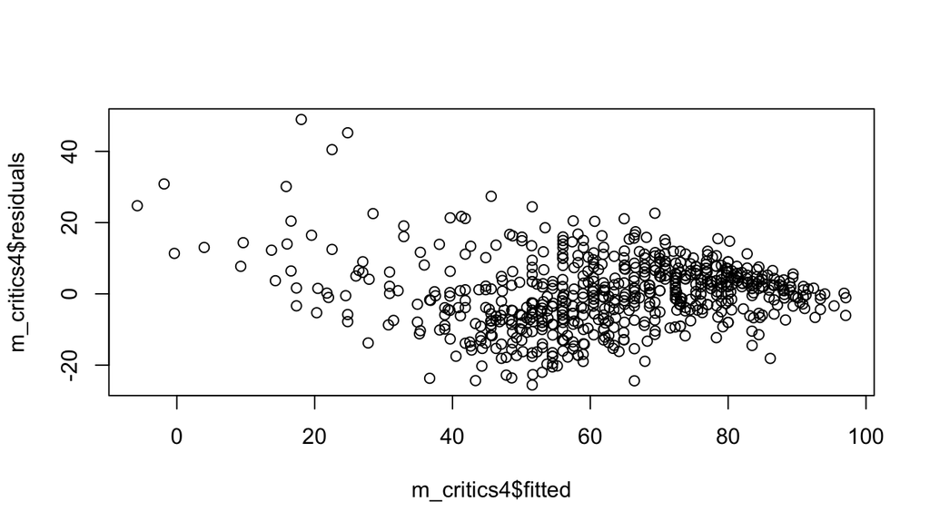

```r
plot(m_critics4$residuals ~ m_critics4$fitted)
```

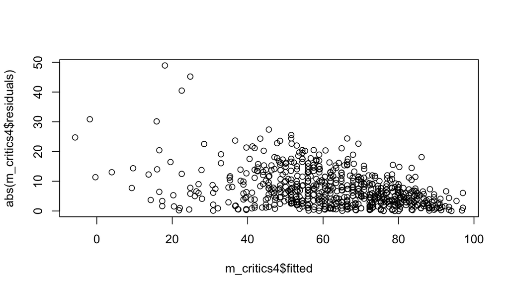

```r
plot(abs(m_critics4$residuals) ~ m_critics4$fitted)
```

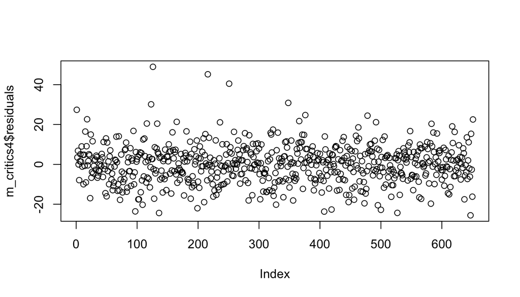

```r
plot(m_critics4$residuals)
```

## Part 5: Prediction

So our prediction model would like this  
y = -30.915  
+ 8.711Animation  
- 0.256Art House  
+ 2.058Comedy  
+ 1.574Documentary  
- 0.132Drama  
- 4.883Horror  
+ 4.717Musical  
- 6.118Suspense  
+ 1.551Other  
- 0776Science  
+ 14.873Imdb Rating  
- 2.209Fresh  
- 5.140*Rotten

Prediction for Popstar:Never Stop Never Stopping IMDB Rating = 6.8 Genre: Comedy, Music Rotten Tomatoes Audience Score = 68% Critics Rating= “Certified Fresh”

y = -30.915 + 2.058 + 4.717 + 14.873 (6.8) y = 76.996%

## Part 6: Conclusion

Even though i started to focus on critics score as one predictor. I eventually dropped it in the final model because the it did not really help in increasing the accuracy of the model. I end up using genre, imdb rating and critics rating because this pushed the confidence level of the model to 76%.